# Name: Cheng Chen NetID: chengc10

### Exercise 1

##### Some infectious diseases have 2 modes of transmission: via direct contact with an infected individual or indirectly by being exposed to an environmental reservoir (for instance, contaminated water). The diagram on the right shows the transmission of one of these diseases, where infected individuals shed virus into the environment reservoir 𝑉 at a rate 𝜔, and pathogens in this reservoir decay at a rate 𝜌. The per capita birth/death rate of the host is given by 𝜇, and infected individuals recover at rate 𝛾.

#### 1a. Write down the system of differential equations

$$\begin{align}
\frac{dS}{dt} &= \mu - \mu S - \beta IS - \beta_v VS \\
\frac{dI}{dt} &= \beta IS + \beta_v VS - \mu I - \gamma I \\
\frac{dR}{dt} &= \gamma I - \mu R \\
\frac{dV}{dt} &= \omega I - \rho V
\end{align}$$

#### 1b. Use the Next Generation Method to show that $R_0 = \frac{\beta}{\mu + \gamma} + \frac{\beta_v \omega}{\rho(\gamma + \mu)}$

In this model, compartments I and V are infected.
$$F_1 = \beta S I + \beta_v V S, V^-_1 = (\mu +
\gamma) I, V^+_1 = 0$$
$$F_2 = 0,
V^-_2 = \rho V, V^+_2 = \omega I$$
$$F =
\begin{bmatrix}
\frac{d(\beta S I + \beta_v V S)}{dI}&\frac{d(\beta S I + \beta_v V
S)}{dV} \\
0&0 \\
\end{bmatrix}
=
\begin{bmatrix}
\beta S^*&\beta_v S^* \\
0&0 \\
\end{bmatrix}
=
\begin{bmatrix}
\beta&\beta_v \\
0&0 \\
\end{bmatrix}$$
where $S^* = 1$ at DFE.

Since $V_i = V^-_i - V^+_i$, then $V_1 = (\mu + \gamma)I$ and $V_2 = \rho V - \omega I$.
$$V =
\begin{bmatrix}
\frac{d((\mu + \gamma)I)}{dI}&\frac{d((\mu + \gamma)I)}{dV} \\
\frac{d(\rho V - \omega I)}{dI}&\frac{d(\rho V - \omega I)}{dV} \\
\end{bmatrix}
=
\begin{bmatrix}
\mu + \gamma&0 \\
-\omega&\rho \\
\end{bmatrix}$$
$$V^{-1} =
\frac{1}{\rho (\mu + \gamma)}
\begin{bmatrix}
\rho&0 \\
\omega&\mu + \gamma \\
\end{bmatrix}
=
\begin{bmatrix}
\frac{1}{\mu + \gamma}&0 \\
\frac{\omega}{\rho (\mu + \gamma)}&\frac{1}{\rho} \\
\end{bmatrix}$$
$$F V^{-1} =
\begin{bmatrix}
\mu + \gamma&0 \\
-\omega&\rho \\
\end{bmatrix}
\begin{bmatrix}
\frac{1}{\mu + \gamma}&0 \\
\frac{\omega}{\rho (\mu + \gamma)}&\frac{1}{\rho} \\
\end{bmatrix}
=
\begin{bmatrix}
\frac{\beta}{\mu + \gamma}+\frac{\beta_v \omega}{\rho (\mu +
\gamma)}&\frac{\beta_v}{\rho} \\
0&0 \\
\end{bmatrix}$$
$R_0$is given by the dominant eigenvalue of $FV^{-1}$
$$det(FV^{-1}- \lambda I) = 0\\
-\lambda(\frac{\beta}{\mu + \gamma}+\frac{\beta_v \omega}{\rho (\mu +
\gamma)}-\lambda) = 0\\
\lambda = \frac{\beta}{\mu + \gamma}+\frac{\beta_v \omega}{\rho (\mu +
\gamma)}$$
$$R_0 = \frac{\beta}{\mu + \gamma}+\frac{\beta_v \omega}{\rho (\mu +
\gamma)}$$

### Exercise 2

##### There is a new outbreak of a respiratory virus on campus. Luckily, there is a vaccine available that provides full protection and immunity doesn’t wane over time. However, Urbana and Champaign proceed with two strategies to contain this outbreak in the long term. Urbana decides to vaccinate 20% of the newborn individuals (𝑝 = 0.2), while Champaign decides to vaccinate the susceptible population at a rate 𝜈 =0.2 𝑦𝑟/0. After 200 years, Champaign has eradicated the virus, while in Urbana, the virus became endemic.

##### The dynamics of this virus can be modeled using the classical SIR model with demography, where 𝛽 =265, the life span for the host (1/𝜇) is 50 years, and the duration of infection (1/𝛾) is 4 days. We will assume no mixing between these two cities.

#### 2a. Estimate $R_0$

$$\gamma = \frac{365}{4} = 91.25 \\
\mu = \frac{1}{50} = 0.02\\
R_0 = \frac{\beta}{\gamma+ \mu} = \frac{265}{91.25 + 0.02} = 2.9$$

#### 2b. Estimate the critical proportion of the newborns $p_c$ that needs to be vaccinated in order to eradicate the pathogen, and discuss why Urbana did not achieve this goal.

$$p_c = 1 - \frac{1}{R_0} = 1 - \frac{1}{2.9} = 0.66 \\
0.2 < 0.66$$
In order to eradicate the pathogen, we need to vaccinate the critical proportion or more. However, only 20% of newborns are vaccinated, which is smaller than the critical proportion(66%). Therefore, Urbana didn’t achieve this goal.

#### 2c. Estimate the critical vaccination rate of susceptible individuals $v_c$ necessary to eradicate the virus, and discuss why Champaign achieved this goal

$$v_c = \mu(R_0 - 1) = 0.02(2.9-1) = 0.038\\
0.2 > 0.038$$
Since Champaign vaccinate the susceptible population at a rate of 0.2, which is higher than the critical vaccination rate of 0.038, Champaign successfully eradicate the virus.

#### 2d. Plot the dynamics of the infected individuals between years 150 and 200, and discuss how these values are related to the outcome observed in Champaign (disease-free) and Urbana (endemicity).

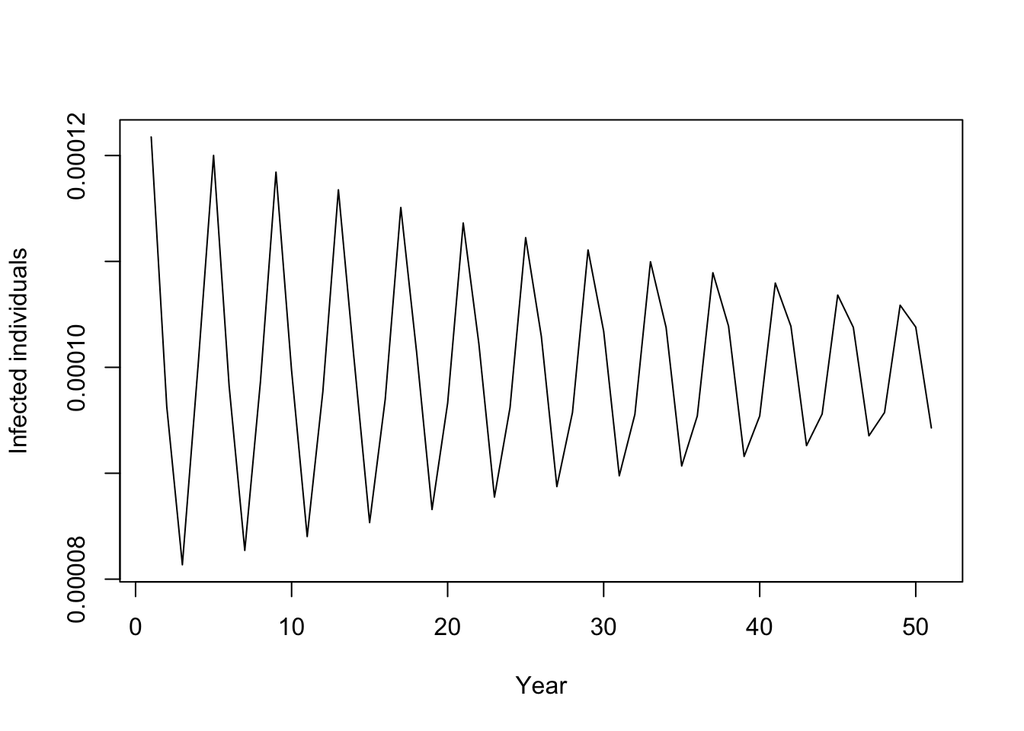

```r
sir_urbana <- function(t, y, pars) {
  S <- y[1]
  I <- y[2]
  R <- y[3]

  beta <- pars["beta"]
  mu <- pars["mu"]
  gamma <- pars["gamma"]
  p <- pars["p"]

  dS <- -beta * S * I - mu * S + mu * (1 - p)
  dI <- beta * S * I - (mu + gamma) * I
  dR <- gamma * I + mu * p - mu * R

  out <- c(dS, dI, dR)
  list(out)
}

init <- c(S = 0.999, I = 0.001, R = 0)
times <- seq(from = 0, to = 200, by = 1)
paras <- c(beta = 265, mu = 0.02, gamma = 91.25, p = 0.2)

data_out <- ode(y = init, times = times, func = sir_urbana, parms = paras)


plot(data_out[150:200,"I"], type = "l", xlab = "Year", ylab = "Infected individuals")
```

According to the plots above, the number of infected people in Urbana oscillates several times between years 150 and 200. The reason for this phenomenon is that the proportion of people vaccinated is smaller than the critical proportion, and people keep getting infected.

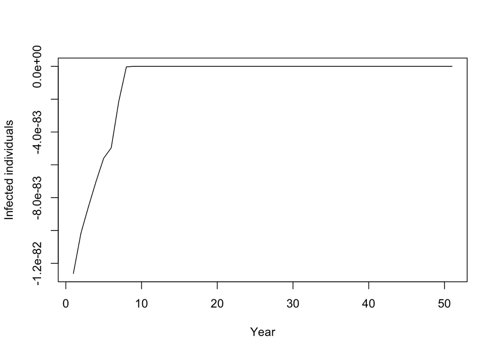

```r
sir_champaign <- function(t, y, pars) {
  S <- y[1]
  I <- y[2]
  R <- y[3]

  beta <- pars["beta"]
  mu <- pars["mu"]
  gamma <- pars["gamma"]
  v <- pars["v"]

  dS <- mu -beta * S * I - v * S - mu * S
  dI <- beta * S * I - (mu + gamma) * I
  dR <- gamma * I + v * S - mu * R

  out <- c(dS, dI, dR)
  list(out)
}

init <- c(S = 0.999, I = 0.001, R = 0)
times <- seq(from = 0, to = 200, by = 1)
paras <- c(beta = 265, mu = 0.02, gamma = 91.25, v = 0.2)

data_out <- ode(y = init, times = times, func = sir_champaign, parms = paras)


plot(data_out[150:200,"I"], type = "l", xlab = "Year", ylab = "Infected individuals")
```

Accoring to the plots above, the number of infected people is almost 0 between year 150 and 200. Since the rate that Champaign vaccinate people is higher than the critical vaccination rate, poeple no longer get infected.